# Urban Fraction for Stratified Beta-binomial Model

# 1 Summary

The complete algorithm of finding those proportions is implemented in two scripts: prepare_thresh.R, thresh.R and they should be run in the order listed. This vignette focuses on finding and downloading the data and highlights some of the major steps.

# 2 Data Source

We need population density surfaces from worldpop.org (related to the script prepare_thresh.R) and Admin-1 level urban population proportion (related to the scripts ur_frac.R and thresh.R) to implement our scripts.

## 2.1 Population density surface

### 2.1.1 1km $\times$ 1km raster for whole population at the year of census

This raster is used for determining the pixel level urban/rural classification for the country of interest. To be consistent with the stratification, we want to use the surface at the year of the sampling frame construction. The year is usually the most recent census and it could be found in the DHS report. The population raster could be manually downloaded from https://www.worldpop.org/geodata/listing?id=75 (unconstrained individual countries 2000-2020 UN adjusted, 1km resolution). The name of the downloaded raster should be like ‘xxx_ppp_2000_1km_Aggregated_UNadj.tif’ where xxx is the three-letter abbreviation for the country (e.g. zmb for Zambia). Then the .tif file should be manually placed into the folder ‘Data\Zambia\Population’. Alternatively, the automated downloading scripts is:

```r
# line 70-90 from prepare_thresh.R
# pop.abbrev and pop_dir are prespecified in the scripts
setwd(pop_dir)

file <- paste0( pop.abbrev,'_ppp_',census.year,'_1km_Aggregated_UNadj.tif')

if(!file.exists(file)){

  url <- paste0("https://data.worldpop.org/GIS/Population/Global_2000_2020_1km_UNadj/",
                census.year, "/", toupper(pop.abbrev),"/",
                pop.abbrev,'_ppp_',census.year,'_1km_Aggregated_UNadj.tif')

  download.file(url, file, method = "libcurl",mode="wb")
}
```

### 2.1.2 100m $\times$ 100m raster for under-5 population at the years for estimation

These rasters are used for aggregating strata specific U5MR. We use worldpop population density broken down by age and sex (available at https://www.worldpop.org/geodata/listing?id=30). For each year, four rasters are needed: 0-1 male (xxx_m_0_year.tif), 1-5 male (xxx_m_1_year.tif), 0-1 female (xxx_f_0_year.tif) and 1-5 female (xxx_f_1_year.tif), where xxx is the three-letter abbreviation for the country. For estiamtes in the past 9 years, 36 rasters in total should be donwloaded. Because of website constraint, the automated downloading scripts might not work well. In that case, manually downloaded .tif files should be put into the folder ‘Data\Zambia\Population’. The automated downloading scripts is:

```r
# line 285-300 from prepare_thresh.R
#! downloading might take a long time, especially for big countries

pop.year <- beg.year:end.year  ## population surface year

setwd(pop_dir)

options(timeout = 1000) # adjust this time, should be longer than each download
for(year in pop.year){
  print(year)
  for(age in c(0, 1)){
    for(sex in c("f", "m")){
      file <- paste0(pop.abbrev,'_', sex, '_', age, '_', year,'.tif')
      if(!file.exists(file)){
        url <- paste0("https://data.worldpop.org/GIS/AgeSex_structures/Global_2000_2020/",
                      year, "/", toupper(pop.abbrev), "/", pop.abbrev, "_",
                      sex, "_", age, "_", year, ".tif")
        download.file(url, file, method = "libcurl",mode="wb")
      }
    }
  }
}
```

## 2.2 Admin-1 level urban population fraction

Our scripts require the information of urban fraction at Admin-1 level. Such information could usually be obtained with credibility from the country-specific DHS survey reports or national census reports. We need to organize this information in a cleaned table to run our scripts.

### 2.2.1 Search for the information about Admin-1 level urban population

It is rare that all the DHS survey reports and national census reports are formatted in the same way, which means that this information might be found at different places in different reports. We provide some general ways to find them and the options are ordered by their priority. We illustrate this process for Zambia.

1. We recommend the reader to first check out the DHS report of the specific survey to be used. Ideally, this information will appear in appendix A. However, in our example, the admin-1 level urban population fraction is not available, and we only have household urban fraction (report available at https://dhsprogram.com/pubs/pdf/FR361/FR361.pdf).
2. The second option is to check out the report for an earlier DHS survey for the same country. DHS surveys usually use the sampling frame as the most recent census. As the census is less frequent than DHS surveys, it is likely (but not necessarily) that multiple DHS surveys share the same sampling frame. This means that the Admin-1 level urban population fraction in previous reports might still be valid to use. One should be cautious about using this approach as the sampling frame might be updated between surveys (such as in Nigeria). In our example, we will go through the final report for DHS 2013-2014 in Zambia (report available at https://dhsprogram.com/pubs/pdf/FR304/FR304.pdf). This time, we found the information in table A.1.

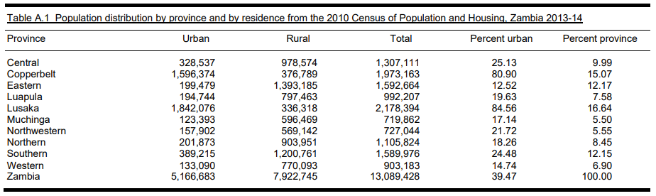

Urban fraction found in Zambia DHS 2013-2014 report

3. If the DHS survey uses the same sampling frame as in the census, the census might also contain the Admin-1 level urban population fraction. From table 2.3 in the report for Zambia census in 2010, we can also obtain the same information.

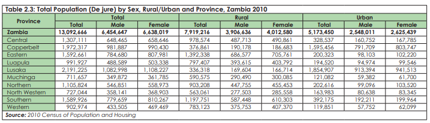

Urban fraction found in Zambia census 2010 report

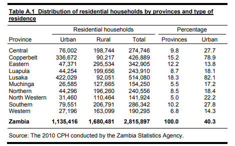

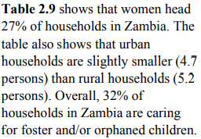

Average households size found in Zambia census 2018 report

### 2.2.2 Organize the information in a cleaned table

After we obtain either the urban and rural population or households and averaged household sizes at Admin-1 level, we need to summarize them in a table for our scripts. This can be done by either running the script “ur_frac.R” after “prepare_thresh.R” and before “thresh.R and or copying directly from the report. The first way is more secure and recommended if there aren’t many Admin-1 regions. The latter is easy to use but might occasionally run into problems due to formatting issues. We first provide some examples to implement”ur_frac.R" below.

Open “ur_frac.R”, select all and run. The first question is to create the summary table in R or Excel.

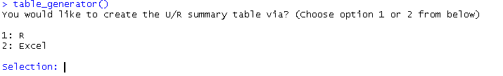

If we choose 1 for the first question by typing 1 in the console and press enter, then the script asks the second question about the type of information we have:

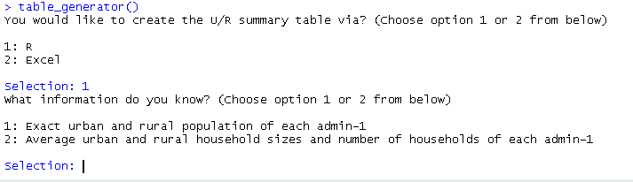

If we choose 2 for the first question, then an empty .xlsx table will be generated and needs to be filled in manually in Excel.

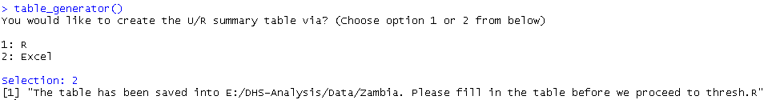

Suppose we know the exact urban and rural population of each Admin-1 region, we choose 1 for the second question. Then, the script asks for the urban and total population for each Admin-1 region. The user needs to type in the number and press enter to proceed to next Admin-1 region until all Admin-1 regions are entered. Finally, the table will be displayed and saved. If a number is entered by mistake, the user can directly correct the saved .xlsx table.

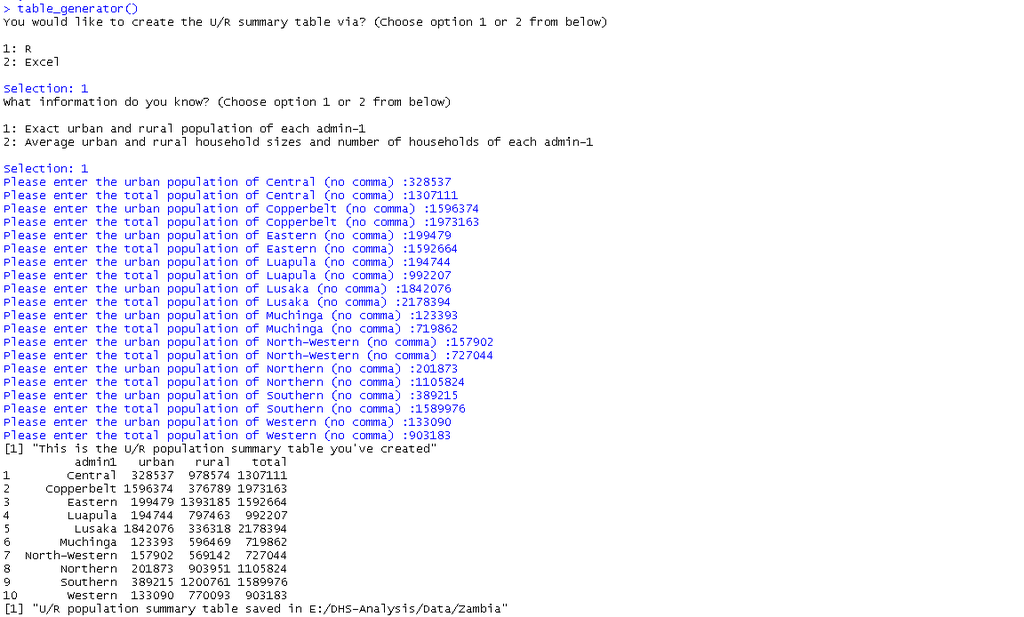

If we choose 2 for the second question, then the script asks for the urban and total households and averaged household sizes for each Admin-1 region. Note that since we know the exact urban and total population of each Admin-1 region for Zambia, then we should always avoid using the household-related information. In the example below, due to the lack of Admin-1 level averaged urban and total household sizes, the national level ones are used, which is not recommended and just for presentation purpose.

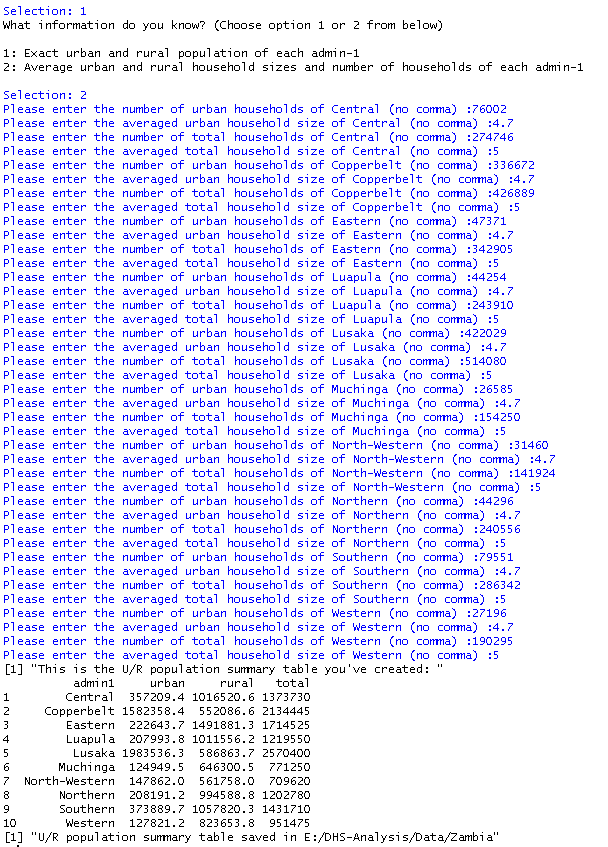

The second way to create such a summary table is directly copying the table from a report. Sometimes, the information of Admin-1 level urban and rural population is well summarized in a table and it is therefore counter-productive to enter the exact numbers manually, especially in the case where there are many Admin-1 regions. Here is an example:

Find our target table and copy the information we need.

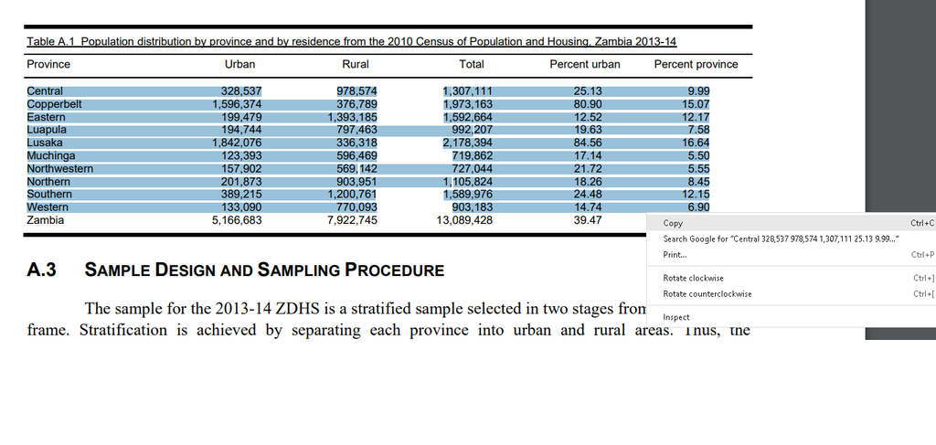

Create an empty .txt file named in the form of “xxx_frame_urb_prop.txt”, where “xxx” is the three-letter country abbreviation in lowercase.

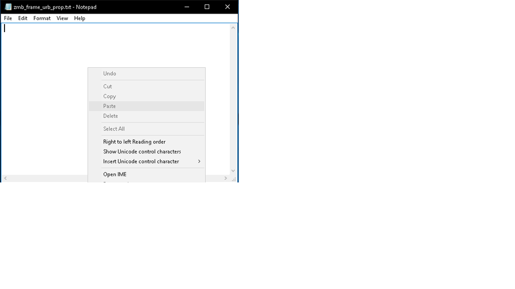

Paste the table and save it in ‘\Data\country\’. Please make sure the first four columns are for the Admin-1 region names, urban population, rural population, and total population respectively. The columns afterwards and the commas in the numbers won’t perturb our scripts.

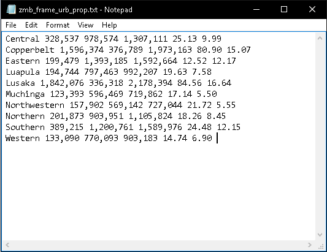

After the Admin-1 urban population fractions are located, we will conduct ad hoc data cleaning to prepare a data frame. We recommend first copy the table from report into a .txt file and clean it in R. The .txt file should be placed under ‘\Data\country\’. We show some details of this step using Zambia as an example. Note that additional scripts might be needed to accommodate country specific situation.